# Exercices in linear models and experimental design GSE136043

Aina Martí

# Introduction

This report can be found in the github repository with link: https://github.com/ainamarti/omics_techniques  
These exercises describe experimental situations that have been studied using some omics technology like microarrays. I have changed my study from previous exercises because the previous one had too many groups and variables to assess, this one is simpler and fits better the requirements for the study.

# Comparison between tumor and non-tumor tissues

This case study is based on a paer published in https://pubmed.ncbi.nlm.nih.gov/32194819/ whose data are available in GEO as series GSE136043 series on the following link https://www.ncbi.nlm.nih.gov/geo/query/acc.cgi?acc=GSE136043

The researchers investigated two types of tissues: In the study presented here, fresh lung cancer tissue specimens and non-tumor lung tissue specimens were collected immediately after surgical resection.

Now we are going to do the analysis using a linear model approach:

```r
require (limma)
library(GEOquery)
exp_set <- getGEO("GSE136043")[[1]]
```

```r
design<-matrix(
  c(1,1,1,1,1,0,0,0,0,0,
    0,0,0,0,0,1,1,1,1,1),
  nrow=10,byrow=F)
design2 <-model.matrix(~ 0+colnames(exp_set))
colnames(design)<-c("T", "N")
rownames(design) <- colnames(exp_set)
print(design)
```

```
##            T N
## GSM4040007 1 0
## GSM4040008 1 0
## GSM4040009 1 0
## GSM4040010 1 0
## GSM4040011 1 0
## GSM4040012 0 1
## GSM4040013 0 1
## GSM4040014 0 1
## GSM4040015 0 1
## GSM4040016 0 1
```

```r
cont.matrix <- makeContrasts (
  TvsN = T-N,
  levels=design)
```

```r
require(limma)
dataMatrix <- exprs(exp_set)
fit<-lmFit(dataMatrix, design)
fit.main<-contrasts.fit(fit, cont.matrix)
fit.main<-eBayes(fit.main)
```

```r
topTab_TvsN <- topTable (fit.main, number=nrow(fit.main), coef="TvsN", adjust="fdr"); head(topTab_TvsN)
```

```
##                   logFC  AveExpr         t      P.Value    adj.P.Val         B
## A_33_P3396008  3.760766 4.330062  20.67831 9.356184e-10 1.851439e-05 11.585088
## A_33_P3240328 -5.540226 5.502657 -20.38116 1.083252e-09 1.851439e-05 11.492314
## A_24_P666105   3.334787 4.156898  17.60842 4.732286e-09 4.238699e-05 10.498719
## A_23_P153301  -6.625296 6.722505 -17.52619 4.960008e-09 4.238699e-05 10.465300
## A_23_P142574   3.127554 5.390414  15.27502 1.959973e-08 1.243477e-04  9.443218
## A_23_P399255   2.921637 6.988695  14.97213 2.391630e-08 1.243477e-04  9.288236
```

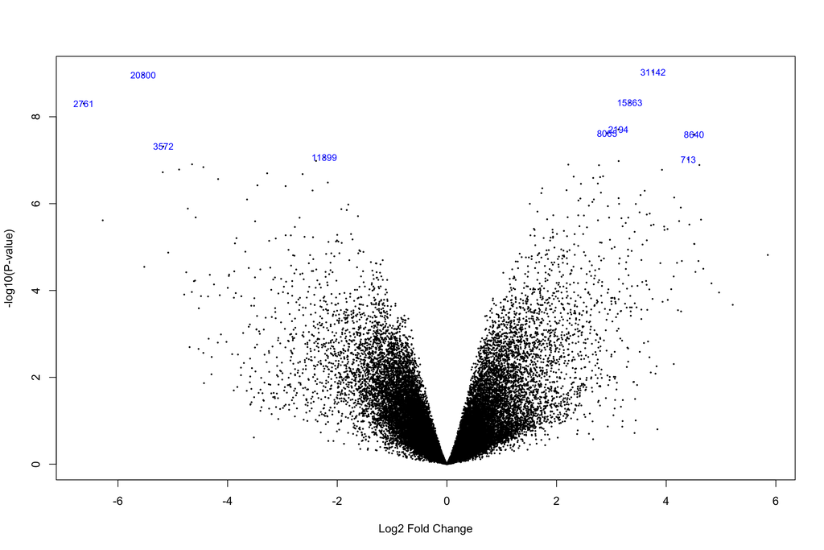

```r
volcanoplot(fit.main, coef="TvsN", highlight=10)
```